# Validity Analysis

ChatGPT 4o

2025-01-21

## 1 起源

效度分析（Validity Analysis）是心理学测量中的关键概念，起源于20世纪初，最早由心理学家Charles Spearman等提出，用于评估测量工具是否能够准确测量所预期的概念。效度分析旨在验证测量工具的有效性，即测量结果是否符合研究者的预期。随着心理测量学的发展，效度分析逐渐被广泛应用于心理学、教育学和社会科学等领域，以确保问卷、测试工具的有效性和科学性。

## 2 原理

效度分析的核心是衡量测量工具的有效性，即测量工具是否能够准确测量出研究者所期望的特质或行为。常见的效度类型包括：

- **内容效度（Content Validity）**：衡量测量工具的内容是否全面代表了所要测量的概念。通常由专家对量表题目进行评估。
- **结构效度（Construct Validity）**：用于验证测量工具的构念结构是否符合理论预期，通常通过因子分析来实现。分为收敛效度和区分效度。
- **收敛效度（Convergent Validity）**：衡量同一构念的不同测量方法之间的相关性是否较高。
- **区分效度（Discriminant Validity）**：衡量不同构念之间的测量结果是否具有较低的相关性。
- **准则效度（Criterion Validity）**：用于衡量测量工具与外部标准之间的相关性，分为同时效度和预测效度。
  - **同时效度（Concurrent Validity）**：测量工具与当前已知有效的标准之间的相关性。
  - **预测效度（Predictive Validity）**：测量工具与未来结果之间的相关性。
- **表面效度（Face Validity）**：衡量测量工具在表面上看是否合理和有效，通常通过非正式的方式评估。

## 3 适用范围

效度分析适用于以下情况：

- **心理测量和教育测评**：评估心理测试、教育测量工具的有效性，确保测量工具能够准确反映所要研究的特质。
- **社会科学调查**：用于评估调查问卷的效度，确保问卷题目能够有效测量研究中的变量。
- **临床诊断**：评估诊断工具或量表的有效性，以确保能够准确诊断患者的症状。

## 4 应用情境

效度分析在多个领域中有广泛的应用，例如：

- **教育学**：用于评估学生测试题的有效性，确保测试题目能够准确衡量学生的知识和技能。
- **心理学**：评估心理测量工具（如人格问卷、情绪量表）的效度，确保量表能够准确反映被测量的心理特质。
- **社会科学研究**：评估调查问卷的效度，确保问卷能够准确衡量社会现象或行为特征。
- **医学领域**：评估健康问卷、生活质量调查工具的效度，以确保临床研究数据的准确性。

## 5 优缺点

### 优点

- **评估工具的有效性**：效度分析能够验证测量工具是否能准确测量所需的概念，提高测量结果的科学性和可信度。
- **帮助改进量表**：通过分析不同类型的效度，研究者可以改进测量工具，使其更符合研究目标。
- **多种类型的效度**：效度分析包括内容效度、结构效度、准则效度等，可以从多个角度评估测量工具的有效性。

### 缺点

- **评估过程复杂**：效度分析通常需要多种方法（如因子分析、专家评估）结合进行，过程较为复杂。
- **主观性较强**：内容效度和表面效度的评估常常依赖专家的主观判断，可能存在一定的偏差。
- **数据要求较高**：结构效度和准则效度的分析通常需要较大的样本量，且需要外部标准数据进行验证。

## 6 在R中的实现及结果解释

在R中，可以使用`lavaan`包进行结构效度的验证性因子分析（CFA），以下是一个使用`lavaan`包进行效度分析的示例：

```r
# 加载必要的包
library(lavaan)
# 示例数据：假设有5个题目用于测量一个潜变量
set.seed(123)
data <- data.frame(
  item1 = sample(1:5, 100, replace = TRUE),
  item2 = sample(1:5, 100, replace = TRUE),
  item3 = sample(1:5, 100, replace = TRUE),
  item4 = sample(1:5, 100, replace = TRUE),
  item5 = sample(1:5, 100, replace = TRUE)
)

# 定义CFA模型
model <- ' latent_variable =~ item1 + item2 + item3 + item4 + item5 '

# 进行验证性因子分析
fit <- cfa(model, data = data)
# 输出CFA结果摘要
summary(fit, fit.measures = TRUE)
```

```
## lavaan 0.6-19 ended normally after 142 iterations
##
##   Estimator                                         ML
##   Optimization method                           NLMINB
##   Number of model parameters                        10
##
##   Number of observations                           100
##
## Model Test User Model:
##
##   Test statistic                                 1.003
##   Degrees of freedom                                 5
##   P-value (Chi-square)                           0.962
##
## Model Test Baseline Model:
##
##   Test statistic                                 7.834
##   Degrees of freedom                                10
##   P-value                                        0.645
##
## User Model versus Baseline Model:
##
##   Comparative Fit Index (CFI)                    1.000
##   Tucker-Lewis Index (TLI)                      -2.691
##
## Loglikelihood and Information Criteria:
##
##   Loglikelihood user model (H0)               -882.461
##   Loglikelihood unrestricted model (H1)       -881.960
##
##   Akaike (AIC)                                1784.923
##   Bayesian (BIC)                              1810.974
##   Sample-size adjusted Bayesian (SABIC)       1779.392
##
## Root Mean Square Error of Approximation:
##
##   RMSEA                                          0.000
##   90 Percent confidence interval - lower         0.000
##   90 Percent confidence interval - upper         0.000
##   P-value H_0: RMSEA <= 0.050                    0.978
```

[output cut: 14 more lines]

```
##   latent_variable =~
##     item1               1.000
##     item2               1.047    1.145    0.915    0.360
##     item3              -1.500    1.395   -1.075    0.282
##     item4             -17.413  114.110   -0.153    0.879
##     item5              -0.032    0.758   -0.042    0.966
##
## Variances:
##                    Estimate  Std.Err  z-value  P(>|z|)
##    .item1             1.951    0.289    6.745    0.000
##    .item2             2.312    0.341    6.791    0.000
##    .item3             2.189    0.367    5.960    0.000
##    .item4            -2.460   26.750   -0.092    0.927
##    .item5             1.974    0.279    7.071    0.000
##     latent_variabl    0.014    0.093    0.148    0.882
```

```r
str(fit)
```

[output not shown]

[output cut: 630 more lines]

[output not shown]

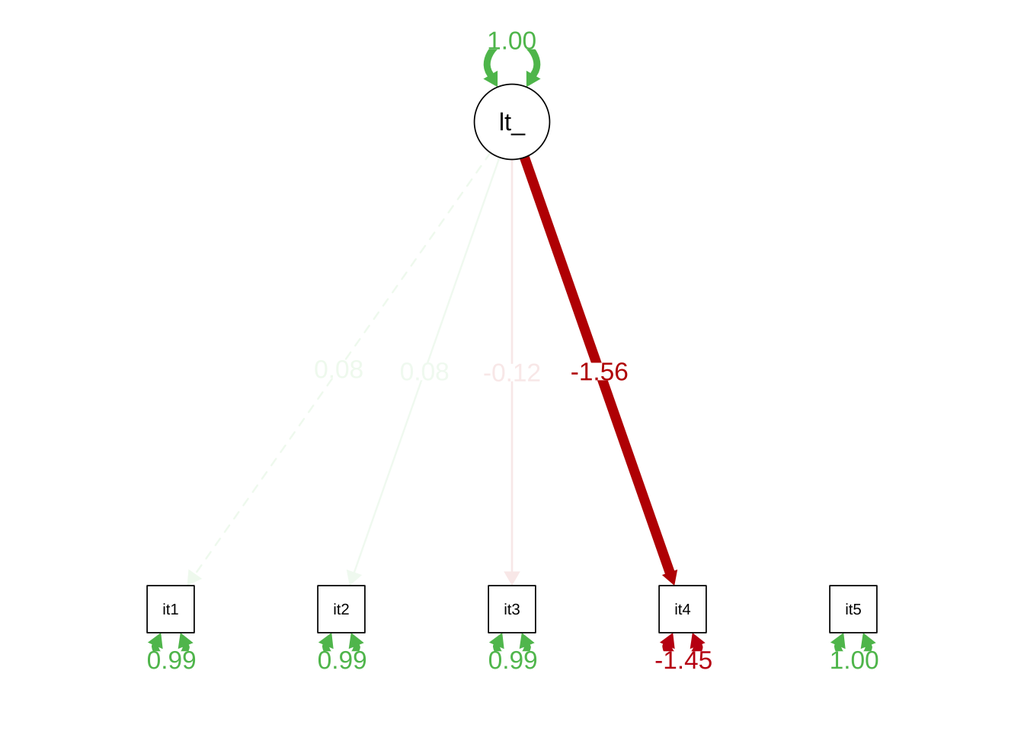

```r
# 可视化：绘制路径图
library(semPlot)
semPaths(fit, "std", layout = "tree", title = FALSE, edge.label.cex = 1.2)
```

### 结果解释

- **CFA结果摘要**：通过`cfa()`函数进行验证性因子分析，使用`summary()`函数可以查看模型的拟合优度指标，包括CFI、TLI、RMSEA等。良好的模型拟合通常表现为CFI和TLI接近1，RMSEA小于0.08。
- **路径图可视化**：通过`semPaths()`函数绘制CFA模型的路径图，图中显示了潜变量与观测变量之间的关系，以及标准化因子负荷值。

### 结果的可视化

效度分析的结果可以通过路径图进行可视化，以直观地展示潜变量与观测变量之间的关系，以及因子负荷的大小。

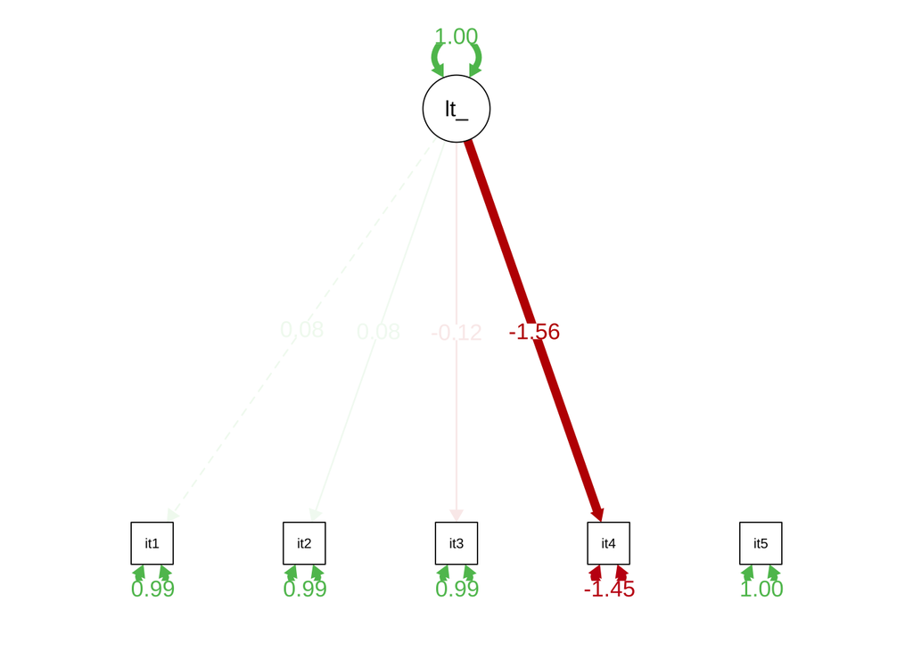

```r
# 使用semPlot包绘制路径图
library(semPlot)
semPaths(fit, "std", layout = "tree", title = FALSE, edge.label.cex = 1.2)
```

## 7 小结

- 效度分析是一种用于评估测量工具是否能够有效测量目标概念的统计方法，广泛应用于心理学、教育学和社会科学等领域。
- 常见的效度类型包括内容效度、结构效度、准则效度等，能够从不同角度评估测量工具的有效性。
- 具有验证测量工具有效性、帮助改进量表等优点，但评估过程较为复杂，部分效度类型具有主观性。
- 可以通过R中的`lavaan`包进行结构效度分析，并结合路径图直观展示潜变量与观测变量之间的关系。